# UD4 N02

# Modelos restringidos en regresión lineal

## Ridge en regresión lineal

Cargamos los datos

```r
library(MASS)
data(Boston)
colnames(Boston)
```

```
 [1] "crim"    "zn"      "indus"   "chas"    "nox"     "rm"      "age"
 [8] "dis"     "rad"     "tax"     "ptratio" "black"   "lstat"   "medv"
```

```r
str(Boston)
```

```
'data.frame':   506 obs. of  14 variables:
 $ crim   : num  0.00632 0.02731 0.02729 0.03237 0.06905 ...
 $ zn     : num  18 0 0 0 0 0 12.5 12.5 12.5 12.5 ...
 $ indus  : num  2.31 7.07 7.07 2.18 2.18 2.18 7.87 7.87 7.87 7.87 ...
 $ chas   : int  0 0 0 0 0 0 0 0 0 0 ...
 $ nox    : num  0.538 0.469 0.469 0.458 0.458 0.458 0.524 0.524 0.524 0.524 ...
 $ rm     : num  6.58 6.42 7.18 7 7.15 ...
 $ age    : num  65.2 78.9 61.1 45.8 54.2 58.7 66.6 96.1 100 85.9 ...
 $ dis    : num  4.09 4.97 4.97 6.06 6.06 ...
 $ rad    : int  1 2 2 3 3 3 5 5 5 5 ...
 $ tax    : num  296 242 242 222 222 222 311 311 311 311 ...
 $ ptratio: num  15.3 17.8 17.8 18.7 18.7 18.7 15.2 15.2 15.2 15.2 ...
 $ black  : num  397 397 393 395 397 ...
 $ lstat  : num  4.98 9.14 4.03 2.94 5.33 ...
 $ medv   : num  24 21.6 34.7 33.4 36.2 28.7 22.9 27.1 16.5 18.9 ...
```

```r
# X <- as.matrix(subset(Boston, select= - medv))
# y <- as.matrix(Boston$medv)
X <- data.matrix(subset(Boston, select= - medv))
y <- Boston$medv
str(X)
```

```
 num [1:506, 1:13] 0.00632 0.02731 0.02729 0.03237 0.06905 ...
 - attr(*, "dimnames")=List of 2
  ..$ : chr [1:506] "1" "2" "3" "4" ...
  ..$ : chr [1:13] "crim" "zn" "indus" "chas" ...
```

Usamos la librería `glmnet`. Ajustamos un modelo de Ridge de regresión lineal, para ello en `Alpha` debemos fijar el valor `0`y en family `'gaussian'` y `type.measure='mse'`

```r
# install.packages("glmnet")
library(glmnet)
set.seed(999)
cv.ridge <- cv.glmnet(X, y, family='gaussian', alpha=0, parallel=TRUE, standardize=TRUE, type.measure='mse')
```

```
executing %dopar% sequentially: no parallel backend registered
```

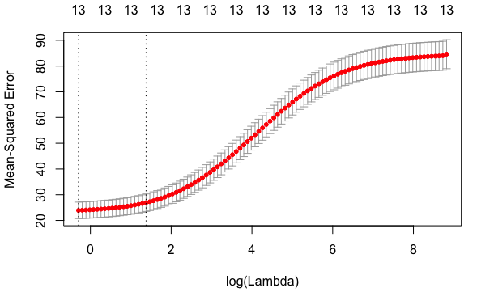

```r
# Resultados
plot(cv.ridge)
```

```r
#este es el mejor valor de lambda
cv.ridge$lambda.min
```

```
[1] 0.7438467
```

```r
#este es el valor del error que se estima para ese valor lambda mínimo dado en MSE
min(cv.ridge$cvm)
```

```
[1] 23.9239
```

```r
var(y)
```

```
[1] 84.58672
```

Esto nos dice los coeficientes para el valor de $\lambda$ óptimo. Observar que bastantes coeficientes son casi nulos:

```r
coef(cv.ridge, s=cv.ridge$lambda.min)
```

```
14 x 1 sparse Matrix of class "dgCMatrix"
                        1
(Intercept)  27.530353913
crim         -0.086503021
zn            0.031944836
indus        -0.040309207
chas          2.906140673
nox         -11.560292622
rm            4.015633667
age          -0.003954324
dis          -1.093642160
rad           0.146667153
tax          -0.005502893
ptratio      -0.848363734
black         0.009044913
lstat        -0.468347041
```

Realizamos una predicción sobre de las primeras dos filas de la matriz

```r
predict.glmnet(cv.ridge$glmnet.fit, newx=X[1:2,], s=cv.ridge$lambda.min)
```

```
         1
1 30.25964
2 25.03138
```

## Lasso en regresión lineal

Para ejecutar un modelo hueco de Lasso sólo tenemos que cambiar `Alpha=0`en la función `glmnet` y aplicarla igual que en el caso Ridge

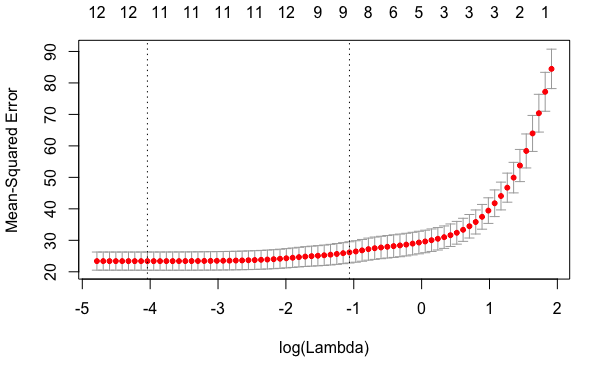

```r
cv.lasso <- cv.glmnet(X, y, family='gaussian', alpha=1, parallel=TRUE, standardize=TRUE, type.measure='mse')
# Resultados
plot(cv.lasso)
```

```r
#este es el mejor valor de lambda
cv.lasso$lambda.min
```

```
[1] 0.01758818
```

```r
#este es el valor del error que se estima para ese valor lambda mínimo dado en MSE
min(cv.lasso$cvm)
```

```
[1] 23.38903
```

Observamos que Lasso arroja resultados de error ligeramente inferiores. Los coeficientes del modelo hueco (con los coeficientes no relevantes establecidos como nulos) son:

```r
coef(cv.lasso, s=cv.lasso$lambda.min)
```

```
14 x 1 sparse Matrix of class "dgCMatrix"
                        1
(Intercept)  35.119429379
crim         -0.101959353
zn            0.043032597
indus         .
chas          2.698519469
nox         -16.696340287
rm            3.843603202
age           .
dis          -1.431281553
rad           0.269539160
tax          -0.010528583
ptratio      -0.936008402
black         0.009123506
lstat        -0.522537970
```

Observamos que “indus” y “age” los ha establecido como nulos directamente.

Realizamos una predicción sobre de las primeras dos filas de la matriz

```r
predict.glmnet(cv.lasso$glmnet.fit, newx=X[1:2,], s=cv.lasso$lambda.min)
```

```
         1
1 30.17952
2 25.03185
```

# Modelos restringidos en regresión logística

Cargamos datos

```r
# install.packages("ElemStatLearn")
library(ElemStatLearn)
data("SAheart")
help(SAheart)
head(SAheart)
```

|  | sbp | tobacco | ldl | adiposity | famhist | typea | obesity | alcohol | age | chd |
| --- | --- | --- | --- | --- | --- | --- | --- | --- | --- | --- |
| 1 | 160 | 12.00 | 5.73 | 23.11 | Present | 49 | 25.30 | 97.20 | 52 | 1 |
| 2 | 144 | 0.01 | 4.41 | 28.61 | Absent | 55 | 28.87 | 2.06 | 63 | 1 |
| 3 | 118 | 0.08 | 3.48 | 32.28 | Present | 52 | 29.14 | 3.81 | 46 | 0 |
| 4 | 170 | 7.50 | 6.41 | 38.03 | Present | 51 | 31.99 | 24.26 | 58 | 1 |
| 5 | 134 | 13.60 | 3.50 | 27.78 | Present | 60 | 25.99 | 57.34 | 49 | 1 |
| 6 | 132 | 6.20 | 6.47 | 36.21 | Present | 62 | 30.77 | 14.14 | 45 | 0 |

```r
#la variable categórica a relacionar es chd
str(SAheart)
```

```
'data.frame':   462 obs. of  10 variables:
 $ sbp      : int  160 144 118 170 134 132 142 114 114 132 ...
 $ tobacco  : num  12 0.01 0.08 7.5 13.6 6.2 4.05 4.08 0 0 ...
 $ ldl      : num  5.73 4.41 3.48 6.41 3.5 6.47 3.38 4.59 3.83 5.8 ...
 $ adiposity: num  23.1 28.6 32.3 38 27.8 ...
 $ famhist  : Factor w/ 2 levels "Absent","Present": 2 1 2 2 2 2 1 2 2 2 ...
 $ typea    : int  49 55 52 51 60 62 59 62 49 69 ...
 $ obesity  : num  25.3 28.9 29.1 32 26 ...
 $ alcohol  : num  97.2 2.06 3.81 24.26 57.34 ...
 $ age      : int  52 63 46 58 49 45 38 58 29 53 ...
 $ chd      : int  1 1 0 1 1 0 0 1 0 1 ...
```

Creamos las matrizes de predictores y variable objetivo

```r
X <- data.matrix(subset(SAheart  , select= - chd))
y <- as.double(as.matrix(SAheart$chd  ))
str(X)
```

```
 num [1:462, 1:9] 160 144 118 170 134 132 142 114 114 132 ...
 - attr(*, "dimnames")=List of 2
  ..$ : chr [1:462] "1" "2" "3" "4" ...
  ..$ : chr [1:9] "sbp" "tobacco" "ldl" "adiposity" ...
```

Vamos a dividir en dos conjuntos, uno de entrenamiento y otro de test, para evlauar la capacidad predictiva de cada modelo:

```r
dim(X)
```

```
[1] 462   9
```

```r
X_train <- X[1:362,]
y_train <- y[1:362]
X_test <- X[363:462,]
y_test <- y[363:462]
```

## Ridge en regresión logística

Se programa igual que el caso lineal, cambiamos a `family='binomial'` y `type.measure='auc'`

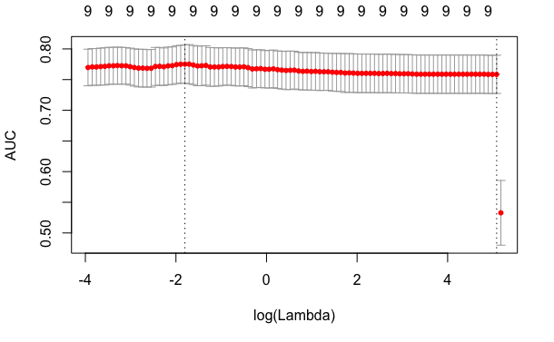

```r
# install.packages("glmnet")
library(glmnet)
set.seed(999)
cv.ridge <- cv.glmnet(X_train, y_train, family='binomial', alpha=0, parallel=TRUE, standardize=TRUE, type.measure='auc')
# Resultados
plot(cv.ridge)
```

```r
#este es el mejor valor de lambda
cv.ridge$lambda.min
```

```
[1] 0.1649506
```

```r
#este es el valor del error que se estima para ese valor lambda mínimo dado en MSE
max(cv.ridge$cvm)
```

```
[1] 0.7752505
```

Vemos los coeficientes

```r
coef(cv.ridge, s=cv.ridge$lambda.min)
```

```
10 x 1 sparse Matrix of class "dgCMatrix"
                       1
(Intercept) -4.401317951
sbp          0.002225867
tobacco      0.051813575
ldl          0.103621507
adiposity    0.015615664
famhist      0.518805985
typea        0.017555785
obesity     -0.010615729
alcohol      0.002323961
age          0.021907907
```

Damos métricas en el test

```r
y_pred <- as.numeric(predict.glmnet(cv.ridge$glmnet.fit, newx=X_test, s=cv.ridge$lambda.min)>.5)
#install.packages(c("e1071", "caret", "e1071")
library(caret)
library(ggplot2)
library(lattice)
library(e1071)
y_test
```

```
  [1] 0 0 1 0 0 0 0 0 1 0 0 0 0 0 0 0 0 1 0 0 1 0 0 1 0 1 0 1 1 1 0 0 0 0 0 1 1 0
 [39] 0 0 1 1 0 0 1 1 0 0 1 0 1 1 0 1 0 0 0 0 0 0 1 1 1 0 0 0 0 0 0 0 0 0 0 0 0 0
 [77] 0 0 0 0 0 0 0 0 1 0 0 1 0 0 0 1 1 1 0 0 1 0 0 1
```

```r
y_pred
```

```
  [1] 0 0 0 0 0 0 0 0 1 0 0 0 0 0 0 0 0 0 0 0 0 0 0 0 0 0 0 0 0 0 0 0 0 0 0 0 0 0
 [39] 0 0 0 0 0 0 1 1 0 0 1 0 1 0 0 0 0 0 0 0 0 0 1 0 0 0 0 0 0 0 0 0 0 0 0 0 0 0
 [77] 0 0 0 0 0 0 0 0 0 0 0 0 0 0 0 0 0 0 0 0 0 0 0 0
```

```r
#confusionMatrix(y_test, y_pred, mode="everything")
confusionMatrix(as.factor(y_test), as.factor(y_pred), mode="everything")
```

```
Confusion Matrix and Statistics

          Reference
Prediction  0  1
         0 71  0
         1 23  6

               Accuracy : 0.77
                 95% CI : (0.6751, 0.8483)
    No Information Rate : 0.94
    P-Value [Acc > NIR] : 1

                  Kappa : 0.2703
 Mcnemar's Test P-Value : 4.49e-06

            Sensitivity : 0.7553
            Specificity : 1.0000
         Pos Pred Value : 1.0000
         Neg Pred Value : 0.2069
              Precision : 1.0000
                 Recall : 0.7553
                     F1 : 0.8606
             Prevalence : 0.9400
         Detection Rate : 0.7100
   Detection Prevalence : 0.7100
      Balanced Accuracy : 0.8777

       'Positive' Class : 0
```

## Lasso en regresión logística

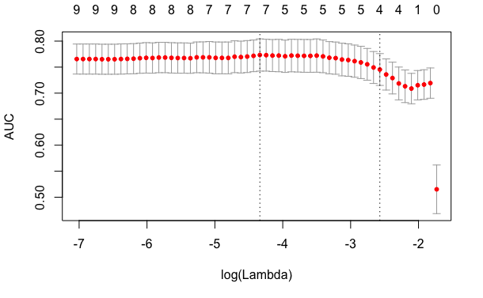

```r
# install.packages("glmnet")
library(glmnet)
set.seed(999)
cv.lasso <- cv.glmnet(X_train, y_train, family='binomial', alpha=1, parallel=TRUE, standardize=TRUE, type.measure='auc')
# Resultados
plot(cv.lasso)
```

```r
#este es el mejor valor de lambda
cv.lasso$lambda.min
```

```
[1] 0.01307205
```

```r
#este es el valor del error que se estima para ese valor lambda mínimo dado en MSE
max(cv.lasso$cvm)
```

```
[1] 0.7733445
```

Vemos los coeficientes

```r
coef(cv.lasso, s=cv.lasso$lambda.min)
```

```
10 x 1 sparse Matrix of class "dgCMatrix"
                        1
(Intercept) -6.0329495868
sbp          .
tobacco      0.0650796752
ldl          0.1415109796
adiposity    .
famhist      0.7523464830
typea        0.0298057710
obesity     -0.0034504452
alcohol      0.0007177487
age          0.0422951288
```

```r
y_pred <- as.numeric(predict.glmnet(cv.lasso$glmnet.fit, newx=X_test, s=cv.lasso$lambda.min)>.5)
#install.packages(c("e1071", "caret", "e1071")
library(caret)
library(ggplot2)
library(lattice)
library(e1071)
#confusionMatrix(y_test, y_pred, mode="everything")
confusionMatrix(as.factor(y_test), as.factor(y_pred), mode="everything")
```

```
Confusion Matrix and Statistics

          Reference
Prediction  0  1
         0 69  2
         1 21  8

               Accuracy : 0.77
                 95% CI : (0.6751, 0.8483)
    No Information Rate : 0.9
    P-Value [Acc > NIR] : 0.9999604

                  Kappa : 0.3072
 Mcnemar's Test P-Value : 0.0001746

            Sensitivity : 0.7667
            Specificity : 0.8000
         Pos Pred Value : 0.9718
         Neg Pred Value : 0.2759
              Precision : 0.9718
                 Recall : 0.7667
                     F1 : 0.8571
             Prevalence : 0.9000
         Detection Rate : 0.6900
   Detection Prevalence : 0.7100
      Balanced Accuracy : 0.7833

       'Positive' Class : 0
```